# chapter-2-freenwood

Shreejit Poudyal

2024-01-30

### Loading Data

```r
dd <- read_csv("https://www.math.montana.edu/courses/s217/documents/Walker2014_mod.csv")
```

```r
mosaicdata <- data(HELPrct)
```

#### Problem 2.1

The tests for the overtake distance data were performed with two-sided alternatives and so two-sided areas used to find the p-values. Suppose that the researchers expected that the average passing distance would be less (closer) for the commute clothing than for the casual clothing group. Repeat obtaining the permutation-based p-value for the one-sided test for either the full or smaller sample data set. Hint: Your p-value should be just about half of what it was before and in the direction of the alternative.

```r
B <- 1000
Ts_dd <- matrix(NA, nrow = B)

dd <- dd %>%
  filter(Condition %in% c("casual", "commute"))
for (b in (1:B)){
  lmP <- lm(Distance ~ shuffle(Condition), data = dd)
  Ts_dd[b] <- coef(lmP)[2]
}
```

```r
summary(lmP)
```

```
##
## Call:
## lm(formula = Distance ~ shuffle(Condition), data = dd)
##
## Residuals:
##      Min       1Q   Median       3Q      Max
## -107.562  -17.561    0.438   16.439  128.439
##
## Coefficients:
##                           Estimate Std. Error t value Pr(>|t|)
## (Intercept)               116.5610     1.0669 109.248   <2e-16 ***
## shuffle(Condition)commute  -0.9985     1.4741  -0.677    0.498
## ---
## Signif. codes:  0 '***' 0.001 '**' 0.01 '*' 0.05 '.' 0.1 ' ' 1
##
## Residual standard error: 29.78 on 1634 degrees of freedom
## Multiple R-squared:  0.0002807,  Adjusted R-squared:  -0.0003311
## F-statistic: 0.4588 on 1 and 1634 DF,  p-value: 0.4983
```

```r
summary(Ts_dd)
```

```
##        V1
##  Min.   :-5.066475
##  1st Qu.:-1.065326
##  Median :-0.004847
##  Mean   :-0.044774
##  3rd Qu.: 0.972313
##  Max.   : 4.424537
```

#### Problem 2.2.

Load the HELPrct data set from the mosaicData package [Pruim et al., 2021a] (you need to install the mosaicData package once to be able to load it). The HELP study was a clinical trial for adult inpatients recruited from a detoxification unit. Patients with no primary care physician were randomly assigned to receive a multidisciplinary assessment and a brief motivational intervention or usual care and various outcomes were observed. Two of the variables in the data set are sex, a factor with levels male and female and daysanysub which is the time (in days) to first use of any substance post-detox. We are interested in the difference in mean number of days to first use of any substance post-detox between males and females. There are some missing responses and the following code will produce `favstats` with the missing values and then provide a data set that by applying the `drop_na()` function to the piped data set removes any observations with missing values.

```r
HELPrct2 <- HELPrct %>%
  select(daysanysub, sex)

HELPrct3 <- HELPrct2 %>%
  drop_na()

favstats(daysanysub ~ sex, data = HELPrct2)
```

```
##      sex min  Q1 median  Q3 max     mean       sd   n missing
## 1 female   0 7.0     33 179 268 83.77193 85.57078  57      50
## 2   male   0 4.5     34 154 260 72.72727 77.26199 187     159
```

```r
favstats(daysanysub ~ sex, data = HELPrct3)
```

```
##      sex min  Q1 median  Q3 max     mean       sd   n missing
## 1 female   0 7.0     33 179 268 83.77193 85.57078  57       0
## 2   male   0 4.5     34 154 260 72.72727 77.26199 187       0
```

#### 2.2.1.

Based on the results provided, how many observations were missing for males and females? Missing values here likely mean that the subjects didn’t use any substances post-detox in the time of the study but might have at a later date – the study just didn’t run long enough. This is called censoring. What is the problem with the numerical summaries here if the missing responses were all something larger than the largest observation? \

Answer: For males, 159 observations were missing and 50 for women were missing. If in case numerical summaries here if the missing responses were all something larger than the largest observation, that would provide biased estimates in favor the recorded values. Moreover, we would also be missing essential data points to be able to make correct conclusions from the data.

#### 2.2.2.

Make a pirate-plot and a boxplot of daysanysub ~ sex using the HELPrct3 data set created above. Compare the distributions, recommending parametric or nonparametric inferences.

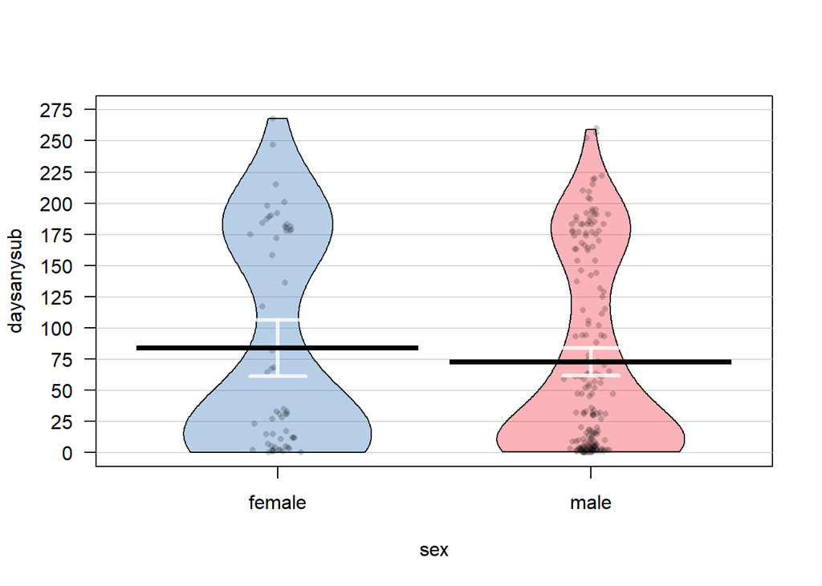

```r
pirateplot(daysanysub ~ sex, data = HELPrct3, inf.method = "ci", inf.disp = "line")
```

#### 2.2.3.

Generate the permutation results and write out the 6+ steps of the hypothesis test.

```r
B <- 1000
Tstar <- matrix(NA, nrow = B)

for (b in (1:B)){
  lmP <- lm(daysanysub ~ shuffle(sex), data = HELPrct3)
  Tstar[b] <- coef(lmP)[2]
}
```

```r
summary(lmP)
```

```
##
## Call:
## lm(formula = daysanysub ~ shuffle(sex), data = HELPrct3)
##
## Residuals:
##    Min     1Q Median     3Q    Max
## -77.25 -69.97 -42.22  88.40 193.28
##
## Coefficients:
##                  Estimate Std. Error t value Pr(>|t|)
## (Intercept)        77.246     10.516   7.346 3.12e-12 ***
## shuffle(sex)male   -2.529     12.012  -0.211    0.833
## ---
## Signif. codes:  0 '***' 0.001 '**' 0.01 '*' 0.05 '.' 0.1 ' ' 1
##
## Residual standard error: 79.39 on 242 degrees of freedom
## Multiple R-squared:  0.0001831,  Adjusted R-squared:  -0.003948
## F-statistic: 0.04433 on 1 and 242 DF,  p-value: 0.8334
```

```r
summary(Tstar)
```

```
##        V1
##  Min.   :-37.6216
##  1st Qu.: -9.0760
##  Median : -0.8465
##  Mean   : -0.7869
##  3rd Qu.:  7.4059
##  Max.   : 41.4455
```

Steps of the hypothesis test * Identify research question/objective, and study data (significance and usage). * What are ways we can understand/visualize the data? * Identify appropriate model/test statistic that is needed for the particular study. * Identify population 1. State the null and alternative hypothesis that the population be based on. 2. State any assumptions made for the analysis, and ensure any conditions for required distributions are met. 3. Calculate the test statistic and the p-value, where the p-value represents the probability of getting the observed test statistic or something more extreme when ${H_0}$ is true. 4. State the conclusion, where if p-value > $\alpha$, then we fail to reject the null hypothesis, or that we do not have enough evidence to support the ${H_a}$. Whereas, if p-value< $\alpha$ then we reject the null hypothesis or that there is enough evidence to conclude in favor of ${H_a}$. 5. Create reports based on findings/data. 6. Discuss implementation of results/scope in real world.

#### 2.2.5.

```r
lm_test <- lm(daysanysub ~ sex, data = HELPrct3)
summary(lm_test)
```

```
##
## Call:
## lm(formula = daysanysub ~ sex, data = HELPrct3)
##
## Residuals:
##    Min     1Q Median     3Q    Max
## -83.77 -68.77 -40.73  90.51 187.27
##
## Coefficients:
##             Estimate Std. Error t value Pr(>|t|)
## (Intercept)    83.77      10.50   7.979 5.88e-14 ***
## sexmale       -11.04      11.99  -0.921    0.358
## ---
## Signif. codes:  0 '***' 0.001 '**' 0.01 '*' 0.05 '.' 0.1 ' ' 1
##
## Residual standard error: 79.26 on 242 degrees of freedom
## Multiple R-squared:  0.003493,   Adjusted R-squared:  -0.0006251
## F-statistic: 0.8482 on 1 and 242 DF,  p-value: 0.358
```

#### 2.2.6.

```r
set.seed(1237)
HELPrct_bst <- resample(HELPrct2)
HELPrct_bst2 <- resample(HELPrct2)

lm1 <- lm(daysanysub ~ sex, data = HELPrct_bst)
Tobs <- coef(lm1)[2]; Tobs
```

```
##   sexmale
## -22.42358
```

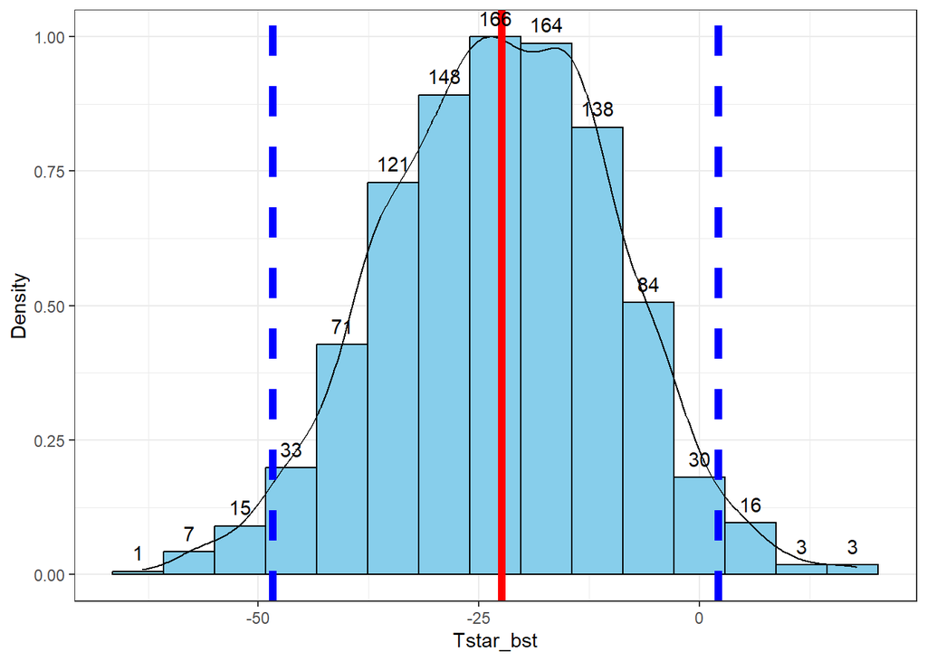

```r
B <- 1000
set.seed(1234)
Tstar_bst <- matrix(NA, nrow = B)
for (b in (1:B)){
  lmP <- lm(daysanysub ~ sex, data = resample(HELPrct_bst))
  Tstar_bst[b] <- coef(lmP)[2]
}

quantiles <- qdata(Tstar_bst, c(0.025,0.975))

tibble(Tstar_bst) %>%
  ggplot(aes(x = Tstar_bst)) +
  geom_histogram(aes(y = ..ncount..), bins = 15, col = 1, fill = "skyblue", center = 0) +
  geom_density(aes(y = ..scaled..)) +
  theme_bw() +
  labs(y = "Density") +
  geom_vline(xintercept = Tobs, col = "red", lwd = 2) +
  geom_vline(xintercept = quantiles, col = "blue", lwd = 2, lty = 2) +
  stat_bin(aes(y = ..ncount.., label = ..count..), bins = 15,
  geom = "text", vjust = -0.75)
```

```r
qdata(Tstar_bst, 0.025)
```

```
##     2.5%
## -48.3966
```

```r
qdata(Tstar_bst, 0.975)
```

```
##  97.5%
## 2.0699
```